# COVID-19 Vaccine Safety Signals in VAERS

Bayesian Disproportionality Analysis Across Nine Vaccine Products

Author

Global Patient Safety

Published

May 5, 2026

```r
library(arrow)
library(dplyr)
library(tidyr)
library(ggplot2)
library(forcats)
library(gt)
library(scales)
library(stringr)

# Aggregated signals (no quarter column) — used for most analyses
SIGNALS_PATH    <- "/srv/shiny-server/gps-patient/data/signals_vaers.parquet"
# Pre-computed first-emergence table (drug, event, first_quarter) — ~85KB
FIRST_SEEN_PATH <- "/srv/shiny-server/gps-patient/data/covid_first_seen.parquet"

label_vaccine <- function(drug) {
  case_when(
    grepl("PFIZER.*BIVALENT|BIVALENT.*PFIZER", drug, ignore.case = TRUE) ~ "Pfizer Bivalent",
    grepl("MODERNA.*BIVALENT|BIVALENT.*MODERNA", drug, ignore.case = TRUE) ~ "Moderna Bivalent",
    grepl("PFIZER|BIONTECH|COMIRNATY",           drug, ignore.case = TRUE) ~ "Pfizer-BioNTech",
    grepl("MODERNA|SPIKEVAX|MNEXSPIKE",           drug, ignore.case = TRUE) ~ "Moderna",
    grepl("JANSSEN|JOHNSON",                      drug, ignore.case = TRUE) ~ "Janssen (J&J)",
    grepl("NOVAVAX",                              drug, ignore.case = TRUE) ~ "Novavax",
    TRUE ~ "Unknown"
  )
}

vaers_raw <- open_dataset(SIGNALS_PATH) |> collect()

covid <- vaers_raw |>
  filter(grepl("COVID|SARS|BNT|MRNA", drug, ignore.case = TRUE)) |>
  mutate(
    vaccine  = label_vaccine(drug),
    platform = case_when(
      vaccine %in% c("Pfizer-BioNTech", "Moderna",
                     "Pfizer Bivalent", "Moderna Bivalent") ~ "mRNA",
      vaccine == "Janssen (J&J)"                            ~ "Viral vector",
      vaccine == "Novavax"                                  ~ "Protein subunit",
      TRUE ~ "Unknown"
    )
  )

# First-emergence: earliest quarter each (drug, event) pair crossed ≥2 methods
first_seen <- open_dataset(FIRST_SEEN_PATH) |>
  collect() |>
  mutate(vaccine = label_vaccine(drug))

# Colour palette — consistent across all plots
vaccine_colours <- c(
  "Pfizer-BioNTech"  = "#1a6b9a",
  "Moderna"          = "#e05f2a",
  "Janssen (J&J)"    = "#2e8b57",
  "Pfizer Bivalent"  = "#6baed6",
  "Moderna Bivalent" = "#fd8d3c",
  "Novavax"          = "#756bb1",
  "Unknown"          = "#bdbdbd"
)
```

## Background

**Note**

VAERS is a passive surveillance system subject to under-reporting, stimulated reporting, and confounding by indication. Signals indicate statistical disproportionality within the reporting database, not established causation. The analysis is descriptive and hypothesis-generating.

## Data Overview

```r
covid |>
  group_by(vaccine, platform) |>
  summarise(
    total_event_pairs  = n(),
    sig_2_plus_methods = sum(n_methods_flagged >= 2),
    sig_3_plus_methods = sum(n_methods_flagged >= 3),
    sig_4_methods      = sum(n_methods_flagged >= 4),
    max_eb05           = round(max(eb05, na.rm = TRUE), 1),
    .groups = "drop"
  ) |>
  arrange(desc(sig_2_plus_methods)) |>
  gt() |>
  tab_header(
    title    = "COVID-19 Vaccine Signal Summary",
    subtitle = "VAERS 1990–present, all methods"
  ) |>
  cols_label(
    vaccine            = "Vaccine",
    platform           = "Platform",
    total_event_pairs  = "Total pairs",
    sig_2_plus_methods = "≥2 methods",
    sig_3_plus_methods = "≥3 methods",
    sig_4_methods      = "4 methods",
    max_eb05           = "Max EB05"
  ) |>
  data_color(
    columns = sig_2_plus_methods,
    palette = "Blues"
  ) |>
  tab_source_note("EB05: lower 95% credible bound of GPS/EBGM estimate.")
```

COVID-19 Vaccine Signal Summary

VAERS 1990–present, all methods

| Vaccine | Platform | Total pairs | ≥2 methods | ≥3 methods | 4 methods | Max EB05 |
| --- | --- | --- | --- | --- | --- | --- |
| Pfizer-BioNTech | mRNA | 2884 | 2884 | 1856 | 379 | 5.3 |
| Moderna | mRNA | 2623 | 2623 | 1937 | 398 | 24.9 |
| Janssen (J&J) | Viral vector | 1827 | 1827 | 1257 | 397 | 55.4 |
| Pfizer Bivalent | mRNA | 1192 | 1192 | 934 | 323 | 61.1 |
| Unknown | Unknown | 758 | 758 | 523 | 254 | 42.7 |
| Moderna Bivalent | mRNA | 668 | 668 | 508 | 188 | 216.9 |
| Novavax | Protein subunit | 191 | 191 | 114 | 40 | 50.2 |

EB05: lower 95% credible bound of GPS/EBGM estimate.

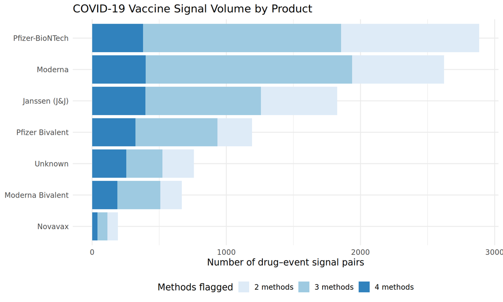

Signal pair counts by number of methods flagged and vaccine product.

```r
covid |>
  mutate(methods_label = case_when(
    n_methods_flagged == 4 ~ "4 methods",
    n_methods_flagged == 3 ~ "3 methods",
    n_methods_flagged == 2 ~ "2 methods",
    TRUE                   ~ "1 method"
  )) |>
  count(vaccine, methods_label) |>
  mutate(
    vaccine        = fct_reorder(vaccine, n, sum),
    methods_label  = factor(methods_label,
                            levels = c("1 method","2 methods","3 methods","4 methods"))
  ) |>
  ggplot(aes(n, vaccine, fill = methods_label)) +
  geom_col() +
  scale_fill_brewer(palette = "Blues", direction = 1) +
  labs(
    x    = "Number of drug–event signal pairs",
    y    = NULL,
    fill = "Methods flagged",
    title = "COVID-19 Vaccine Signal Volume by Product"
  ) +
  theme_minimal(base_size = 13) +
  theme(legend.position = "bottom")
```

## Key Findings by Clinical Domain

### Thrombosis with Thrombocytopenia Syndrome (TTS)

The most product-specific signal in the dataset. Janssen (J&J) shows EB05 = 18.4 flagged by all four methods for TTS, corroborating the regulatory finding that ultimately led to Janssen’s restricted and then discontinued use in the United States. Supporting diagnostic signals — heparin-induced thrombocytopenia tests, anti-platelet factor 4 antibody, cerebral thrombosis — form a consistent mechanistic cluster.

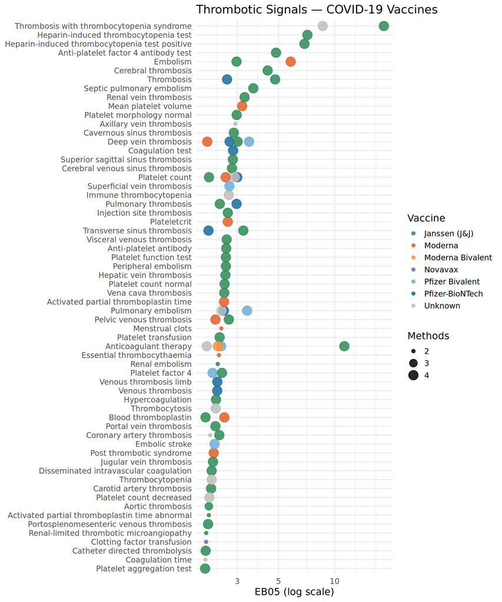

Thrombotic and clotting signals (EB05 > 2, ≥2 methods). Point size proportional to number of methods flagged.

```r
thromb <- covid |>
  filter(
    grepl("thrombo|embol|clot|coagul|disseminated|purpura|platelet|heparin|anti-platelet",
          event, ignore.case = TRUE),
    n_methods_flagged >= 2,
    eb05 > 2
  ) |>
  mutate(event = str_trunc(event, 55))

ggplot(thromb, aes(eb05, fct_reorder(event, eb05), colour = vaccine, size = n_methods_flagged)) +
  geom_point(alpha = 0.85) +
  scale_colour_manual(values = vaccine_colours) +
  scale_size_continuous(range = c(2, 6), breaks = 2:4) +
  scale_x_log10() +
  labs(
    x      = "EB05 (log scale)",
    y      = NULL,
    colour = "Vaccine",
    size   = "Methods",
    title  = "Thrombotic Signals — COVID-19 Vaccines"
  ) +
  theme_minimal(base_size = 14) +
  theme(
    legend.position = "right",
    axis.text.y     = element_text(size = 11)
  )
```

```r
covid |>
  filter(
    grepl("thrombo|embol|heparin|anti-platelet|platelet factor",
          event, ignore.case = TRUE),
    n_methods_flagged >= 2
  ) |>
  left_join(first_seen |> select(drug, event, first_quarter),
            by = c("drug", "event")) |>
  arrange(desc(eb05)) |>
  select(vaccine, event, eb05, n_methods_flagged, first_quarter) |>
  head(20) |>
  gt() |>
  tab_header(title = "Top Thrombotic Signals (≥2 methods)") |>
  cols_label(
    vaccine           = "Vaccine",
    event             = "Event",
    eb05              = "EB05",
    n_methods_flagged = "Methods",
    first_quarter     = "First flagged"
  ) |>
  fmt_number(eb05, decimals = 1) |>
  tab_style(
    style     = cell_fill(color = "#fff3cd"),
    locations = cells_body(rows = vaccine == "Janssen (J&J)")
  )
```

Top Thrombotic Signals (≥2 methods)

| Vaccine | Event | EB05 | Methods | First flagged |
| --- | --- | --- | --- | --- |
| Janssen (J&J) | Thrombosis with thrombocytopenia syndrome | 18.4 | 4 | 2021Q3 |
| Unknown | Thrombosis with thrombocytopenia syndrome | 8.6 | 4 | 2021Q4 |
| Janssen (J&J) | Heparin-induced thrombocytopenia test | 7.1 | 4 | 2021Q2 |
| Janssen (J&J) | Heparin-induced thrombocytopenia test positive | 6.9 | 4 | 2021Q2 |
| Moderna | Embolism | 5.8 | 4 | 2025Q4 |
| Janssen (J&J) | Anti-platelet factor 4 antibody test | 4.9 | 4 | 2022Q3 |
| Janssen (J&J) | Thrombosis | 4.8 | 4 | 2021Q2 |
| Janssen (J&J) | Cerebral thrombosis | 4.4 | 4 | 2021Q2 |
| Janssen (J&J) | Septic pulmonary embolism | 3.7 | 4 | 2021Q4 |
| Pfizer Bivalent | Deep vein thrombosis | 3.5 | 4 | 2023Q4 |
| Pfizer Bivalent | Pulmonary embolism | 3.4 | 4 | 2024Q1 |
| Janssen (J&J) | Renal vein thrombosis | 3.3 | 4 | 2021Q3 |
| Janssen (J&J) | Transverse sinus thrombosis | 3.2 | 4 | 2021Q2 |
| Janssen (J&J) | Deep vein thrombosis | 3.0 | 4 | 2021Q2 |
| Pfizer-BioNTech | Pulmonary thrombosis | 3.0 | 4 | 2021Q1 |
| Janssen (J&J) | Embolism | 3.0 | 4 | 2023Q1 |
| Unknown | Axillary vein thrombosis | 2.9 | 2 | 2021Q2 |
| Janssen (J&J) | Cavernous sinus thrombosis | 2.9 | 4 | 2021Q2 |
| Janssen (J&J) | Superior sagittal sinus thrombosis | 2.8 | 4 | 2021Q2 |
| Janssen (J&J) | Cerebral venous sinus thrombosis | 2.8 | 4 | 2021Q2 |

### Cardiac Signals

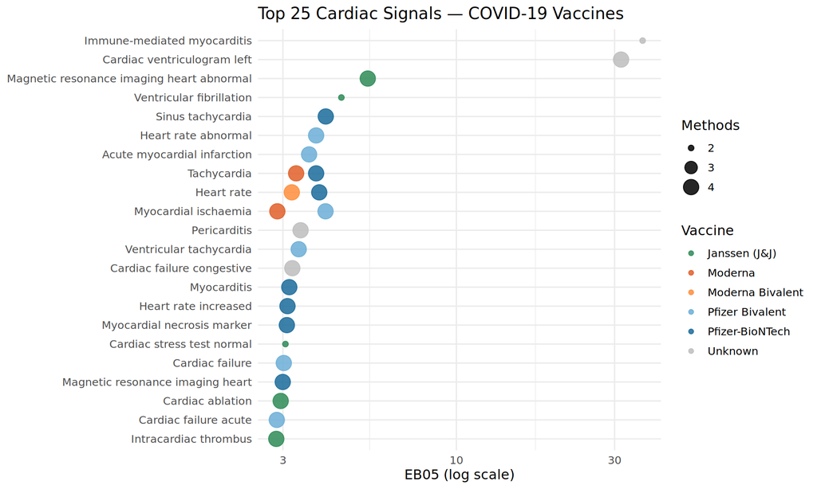

Cardiac signals (EB05 > 2, ≥2 methods). Immune-mediated myocarditis is the top signal by EB05.

```r
cardiac <- covid |>
  filter(
    grepl("myocard|pericard|cardiac|heart|tachycard|arrhyth|infarct|fibrillat|ventriculogram",
          event, ignore.case = TRUE),
    n_methods_flagged >= 2,
    eb05 > 2
  ) |>
  arrange(desc(eb05)) |>
  slice_head(n = 25) |>
  mutate(event = str_trunc(event, 50))

ggplot(cardiac, aes(eb05, fct_reorder(event, eb05), colour = vaccine, size = n_methods_flagged)) +
  geom_point(alpha = 0.85) +
  scale_colour_manual(values = vaccine_colours) +
  scale_size_continuous(range = c(2, 6), breaks = 2:4) +
  scale_x_log10() +
  labs(
    x      = "EB05 (log scale)",
    y      = NULL,
    colour = "Vaccine",
    size   = "Methods",
    title  = "Top 25 Cardiac Signals — COVID-19 Vaccines"
  ) +
  theme_minimal(base_size = 12)
```

### Neurological Signals

Janssen carries the heaviest neurological signal burden: Guillain-Barré syndrome (EB05 = 2.75), chronic inflammatory demyelinating polyneuropathy (CIDP, EB05 = 3.0), and peripheral motor neuropathy (EB05 = 3.6), all flagged by ≥2 methods. Facial nerve/Bell’s palsy and demyelinating conditions appear across mRNA products at lower EB05 magnitudes.

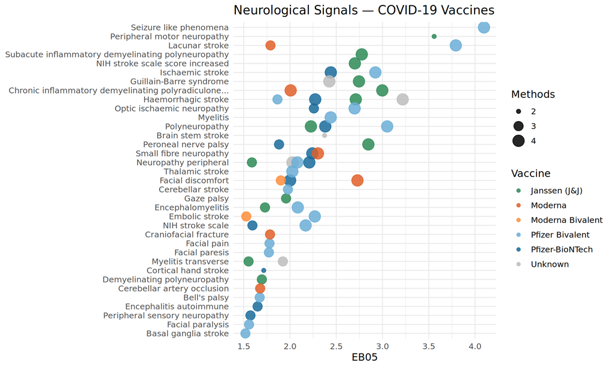

Neurological signals (EB05 > 1.5, ≥2 methods).

```r
neuro <- covid |>
  filter(
    grepl("guillain|bell|palsy|encephalit|myelit|neuropath|seizure|convuls|stroke|facial|demyelinat|polyneurop",
          event, ignore.case = TRUE),
    n_methods_flagged >= 2,
    eb05 > 1.5
  ) |>
  mutate(event = str_trunc(event, 52))

ggplot(neuro, aes(eb05, fct_reorder(event, eb05), colour = vaccine, size = n_methods_flagged)) +
  geom_point(alpha = 0.85) +
  scale_colour_manual(values = vaccine_colours) +
  scale_size_continuous(range = c(2, 6), breaks = 2:4) +
  labs(
    x      = "EB05",
    y      = NULL,
    colour = "Vaccine",
    size   = "Methods",
    title  = "Neurological Signals — COVID-19 Vaccines"
  ) +
  theme_minimal(base_size = 12)
```

### Anaphylaxis and Hypersensitivity

```r
covid |>
  filter(
    grepl("anaphylax|hypersensit|allerg|angioedema",
          event, ignore.case = TRUE),
    n_methods_flagged >= 2
  ) |>
  arrange(desc(eb05)) |>
  select(vaccine, event, eb05, n_methods_flagged) |>
  gt() |>
  tab_header(title = "Anaphylaxis and Hypersensitivity Signals (≥2 methods)") |>
  cols_label(
    vaccine           = "Vaccine",
    event             = "Event",
    eb05              = "EB05",
    n_methods_flagged = "Methods"
  ) |>
  fmt_number(eb05, decimals = 2)
```

Anaphylaxis and Hypersensitivity Signals (≥2 methods)

| Vaccine | Event | EB05 | Methods |
| --- | --- | --- | --- |
| Moderna | Type I hypersensitivity | 5.01 | 4 |
| Unknown | Drug hypersensitivity | 3.86 | 4 |
| Moderna | Allergy test | 2.54 | 4 |
| Moderna | Type IV hypersensitivity reaction | 2.44 | 4 |
| Pfizer-BioNTech | Allergic reaction to excipient | 2.35 | 4 |
| Moderna | Angioedema | 2.32 | 4 |
| Novavax | Allergy to vaccine | 2.10 | 2 |
| Moderna | Injection site hypersensitivity | 2.06 | 4 |
| Novavax | Type II hypersensitivity | 2.06 | 2 |
| Moderna | Allergy test negative | 1.99 | 3 |
| Moderna | Allergy test positive | 1.87 | 3 |
| Pfizer-BioNTech | Vaccination site hypersensitivity | 1.76 | 3 |
| Pfizer-BioNTech | Allergy test | 1.58 | 3 |
| Janssen (J&J) | Multiple allergies | 1.52 | 3 |
| Moderna | Allergy to chemicals | 1.49 | 3 |
| Pfizer-BioNTech | Type I hypersensitivity | 1.49 | 3 |
| Moderna | Allergy to vaccine | 1.48 | 3 |
| Moderna | Seasonal allergy | 1.37 | 3 |
| Pfizer-BioNTech | Allergy to vaccine | 1.24 | 3 |
| Pfizer-BioNTech | Allergic oedema | 1.21 | 2 |
| Moderna | Allergy to animal | 1.20 | 3 |
| Pfizer-BioNTech | Drug hypersensitivity | 1.20 | 3 |
| Moderna | Allergy to metals | 1.20 | 3 |
| Moderna | Anaphylaxis prophylaxis | 1.19 | 2 |
| Moderna | Infusion related hypersensitivity reaction | 1.18 | 3 |
| Moderna | Vaccination site hypersensitivity | 1.17 | 3 |
| Pfizer-BioNTech | Angioedema | 1.16 | 2 |
| Pfizer-BioNTech | Hypersensitivity | 1.16 | 2 |
| Unknown | Hypersensitivity | 1.14 | 2 |
| Pfizer-BioNTech | Allergy to chemicals | 1.14 | 3 |
| Moderna | Caffeine allergy | 1.13 | 2 |
| Janssen (J&J) | Seasonal allergy | 1.13 | 2 |
| Pfizer-BioNTech | Seasonal allergy | 1.12 | 2 |
| Pfizer-BioNTech | Multiple allergies | 1.11 | 2 |
| Moderna | Mycotic allergy | 1.11 | 2 |
| Moderna | Hypersensitivity | 1.11 | 2 |
| Janssen (J&J) | Injection site hypersensitivity | 1.10 | 2 |
| Unknown | Angioedema | 1.10 | 2 |
| Pfizer Bivalent | Allergy test positive | 1.09 | 2 |
| Pfizer-BioNTech | Hypersensitivity vasculitis | 1.08 | 2 |
| Moderna | Food allergy | 1.08 | 2 |
| Pfizer-BioNTech | Polymers allergy | 0.96 | 2 |
| Pfizer-BioNTech | Conjunctivitis allergic | 0.96 | 2 |
| Pfizer-BioNTech | Allergy to arthropod bite | 0.96 | 2 |
| Pfizer-BioNTech | Eye allergy | 0.96 | 2 |

Moderna shows the strongest Type I hypersensitivity signal (EB05 = 5.0, 4 methods). Novavax — the protein-subunit product — shows allergy-to-vaccine and Type II hypersensitivity signals, consistent with its adjuvant-driven mechanism.

## Pfizer-BioNTech vs Moderna: Head-to-Head Comparison

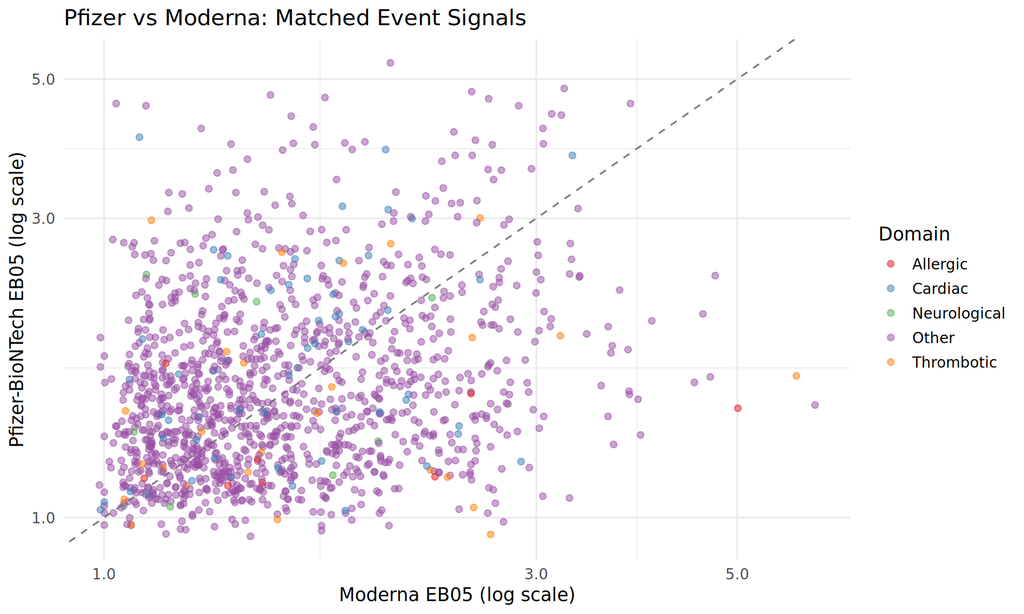

Pfizer vs Moderna EB05 for events flagged by both products (≥2 methods). Dashed line = parity. Points above the line have higher Pfizer signal strength.

```r
pf  <- covid |> filter(vaccine == "Pfizer-BioNTech", n_methods_flagged >= 2) |>
       select(event, eb05_pfizer = eb05)
mod <- covid |> filter(vaccine == "Moderna",         n_methods_flagged >= 2) |>
       select(event, eb05_moderna = eb05)

both <- inner_join(pf, mod, by = "event") |>
  mutate(
    domain = case_when(
      grepl("myocard|pericard|cardiac|heart|tachycard|arrhyth|infarct", event, ignore.case=TRUE) ~ "Cardiac",
      grepl("thrombo|embol|coagul|platelet",                            event, ignore.case=TRUE) ~ "Thrombotic",
      grepl("guillain|neuropath|encephalit|myelit|seizure|stroke",      event, ignore.case=TRUE) ~ "Neurological",
      grepl("anaphylax|allerg|hypersensit|angioedema",                  event, ignore.case=TRUE) ~ "Allergic",
      TRUE ~ "Other"
    )
  )

ggplot(both, aes(eb05_moderna, eb05_pfizer, colour = domain)) +
  geom_abline(slope = 1, intercept = 0, linetype = "dashed", colour = "grey50") +
  geom_point(alpha = 0.5, size = 1.8) +
  scale_x_log10(labels = label_number(accuracy = 0.1)) +
  scale_y_log10(labels = label_number(accuracy = 0.1)) +
  scale_colour_brewer(palette = "Set1") +
  labs(
    x      = "Moderna EB05 (log scale)",
    y      = "Pfizer-BioNTech EB05 (log scale)",
    colour = "Domain",
    title  = "Pfizer vs Moderna: Matched Event Signals"
  ) +
  theme_minimal(base_size = 13)
```

## Signal Emergence Timeline

When did each signal first cross the ≥2 method threshold? The chart below shows the first quarter a signal was detected for each vaccine product, ordered by emergence date. Signals appearing in 2020-Q4 or 2021-Q1 reflect the earliest post-authorisation reporting period; later emergence suggests either rare events requiring larger exposure denominators or signals specific to booster/bivalent formulations.

[figure not shown]

Quarter of first detection (≥2 methods) for the top 40 COVID vaccine signals by EB05. Each point is one (vaccine, event) pair.

```r
top40_events <- covid |>
  filter(n_methods_flagged >= 2) |>
  group_by(event) |>
  summarise(max_eb05 = max(eb05), .groups = "drop") |>
  arrange(desc(max_eb05)) |>
  slice_head(n = 40) |>
  pull(event)

first_seen |>
  filter(event %in% top40_events) |>
  mutate(
    event         = str_trunc(event, 50),
    first_quarter = as.Date(paste0(
      str_extract(first_quarter, "^\\d{4}"), "-",
      sprintf("%02d", (as.integer(str_extract(first_quarter, "\\d$")) - 1L) * 3L + 1L),
      "-01"
    ))
  ) |>
  ggplot(aes(first_quarter, fct_reorder(event, first_quarter, min),
             colour = vaccine)) +
  geom_point(size = 3, alpha = 0.85) +
  scale_colour_manual(values = vaccine_colours) +
  scale_x_date(date_breaks = "6 months", date_labels = "%Y-Q%q") +
  labs(
    x      = "First quarter flagged",
    y      = NULL,
    colour = "Vaccine",
    title  = "Signal Emergence — Top 40 COVID Vaccine Signals"
  ) +
  theme_minimal(base_size = 12) +
  theme(
    axis.text.x = element_text(angle = 35, hjust = 1),
    axis.text.y = element_text(size = 10)
  )
```

```r
covid |>
  filter(n_methods_flagged >= 2, eb05 > 3) |>
  left_join(first_seen |> select(drug, event, first_quarter),
            by = c("drug", "event")) |>
  arrange(first_quarter, desc(eb05)) |>
  select(first_quarter, vaccine, event, eb05, n_methods_flagged) |>
  gt() |>
  tab_header(
    title    = "High-Magnitude Signals by First Detection Quarter",
    subtitle = "EB05 > 3, ≥2 methods flagged"
  ) |>
  cols_label(
    first_quarter     = "First flagged",
    vaccine           = "Vaccine",
    event             = "Event",
    eb05              = "EB05",
    n_methods_flagged = "Methods"
  ) |>
  fmt_number(eb05, decimals = 1) |>
  tab_row_group(
    label = "2020",
    rows  = grepl("^2020", first_quarter)
  ) |>
  tab_row_group(
    label = "2021",
    rows  = grepl("^2021", first_quarter)
  ) |>
  tab_row_group(
    label = "2022+",
    rows  = grepl("^202[2-9]|^203", first_quarter)
  ) |>
  data_color(columns = eb05, palette = "Blues")
```

High-Magnitude Signals by First Detection Quarter

EB05 > 3, ≥2 methods flagged

| First flagged | Vaccine | Event | EB05 | Methods |
| --- | --- | --- | --- | --- |
| 2022+ |  |  |  |  |
| 2022Q1 | Janssen (J&J) | Tenoplasty | 34.7 | 3 |
| 2022Q1 | Unknown | Therapeutic product effect decreased | 12.4 | 4 |
| 2022Q1 | Janssen (J&J) | Labour pain | 6.6 | 4 |
| 2022Q1 | Janssen (J&J) | Pulmonary tuberculosis | 6.4 | 4 |
| 2022Q1 | Janssen (J&J) | Diabetic foot | 5.0 | 4 |
| 2022Q1 | Unknown | Vascular operation | 4.5 | 2 |
| 2022Q1 | Moderna | Urticaria chronic | 3.5 | 4 |
| 2022Q1 | Unknown | Renal disorder | 3.4 | 4 |
| 2022Q1 | Janssen (J&J) | Hepatitis A antibody negative | 3.3 | 4 |
| 2022Q1 | Moderna | Immunisation reaction | 3.1 | 4 |
| 2022Q2 | Unknown | Cardiac ventriculogram left | 31.4 | 4 |
| 2022Q2 | Unknown | Dental caries | 15.6 | 4 |
| 2022Q2 | Janssen (J&J) | Disability | 10.7 | 4 |
| 2022Q2 | Unknown | Product dose omission issue | 8.4 | 4 |
| 2022Q2 | Janssen (J&J) | Local reaction | 8.1 | 4 |
| 2022Q2 | Unknown | Interleukin level | 6.5 | 4 |
| 2022Q2 | Unknown | Foetal exposure during pregnancy | 6.2 | 4 |
| 2022Q2 | Unknown | Cytokine test | 5.9 | 4 |
| 2022Q2 | Janssen (J&J) | SARS-CoV-2 test | 5.5 | 4 |
| 2022Q2 | Janssen (J&J) | Acoustic stimulation tests | 5.3 | 4 |
| 2022Q2 | Unknown | Still's disease | 5.2 | 4 |
| 2022Q2 | Janssen (J&J) | Acid peptic disease | 4.6 | 4 |
| 2022Q2 | Moderna | Product storage error | 4.0 | 4 |
| 2022Q2 | Unknown | Wound | 3.5 | 4 |
| 2022Q2 | Unknown | Nephrotic syndrome | 3.4 | 4 |
| 2022Q2 | Unknown | Histology | 3.4 | 4 |
| 2022Q2 | Unknown | Blood pressure diastolic increased | 3.3 | 4 |
| 2022Q2 | Unknown | Protein urine | 3.2 | 4 |
| 2022Q2 | Janssen (J&J) | Ultrasound antenatal screen | 3.1 | 4 |

[output cut: 592 more lines]

## Platform Comparison

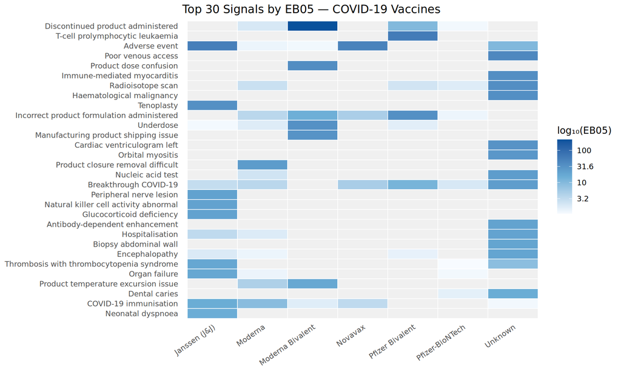

Top 30 events by maximum EB05 across all products, shown for each vaccine. Grey = not flagged at ≥2 methods.

```r
top_events <- covid |>
  filter(n_methods_flagged >= 2) |>
  group_by(event) |>
  summarise(max_eb05 = max(eb05), .groups = "drop") |>
  arrange(desc(max_eb05)) |>
  slice_head(n = 30) |>
  pull(event)

heatmap_data <- covid |>
  filter(event %in% top_events, n_methods_flagged >= 2) |>
  select(vaccine, event, eb05) |>
  complete(vaccine, event, fill = list(eb05 = NA)) |>
  mutate(event = str_trunc(event, 48))

ggplot(heatmap_data,
       aes(vaccine, fct_reorder(event, eb05, max, na.rm = TRUE), fill = log10(eb05 + 0.01))) +
  geom_tile(colour = "white", linewidth = 0.3) +
  scale_fill_gradientn(
    colours  = c("#f7fbff", "#6baed6", "#08519c"),
    na.value = "#f0f0f0",
    name     = "log₁₀(EB05)",
    labels   = function(x) round(10^x, 1)
  ) +
  labs(
    x     = NULL,
    y     = NULL,
    title = "Top 30 Signals by EB05 — COVID-19 Vaccines"
  ) +
  theme_minimal(base_size = 11) +
  theme(
    axis.text.x  = element_text(angle = 35, hjust = 1),
    panel.grid   = element_blank()
  )
```

## Interpretation Summary

| Domain | Key finding | Product(s) |
| --- | --- | --- |
| Thrombosis | TTS cluster — EB05 18.4, all 4 methods | Janssen |
| Cardiac | Immune-mediated myocarditis EB05 36.5; cardiac cluster in bivalent boosters | mRNA (unspecified); Pfizer Bivalent |
| Neurological | GBS, CIDP, demyelinating conditions | Janssen (strongest); mRNA (lower magnitude) |
| Allergic | Type I hypersensitivity EB05 5.0; adjuvant-related signals | Moderna; Novavax |
| Post-COVID | Post-acute COVID-19 syndrome flagged by both mRNA products | Pfizer, Moderna |

The Janssen product’s disproportionate representation in thrombotic and neurological signal clusters — relative to its dose volume — is the dominant cross-domain finding and is consistent with published regulatory assessments. The mRNA products share a large, lower-magnitude signal landscape dominated by reactogenicity, cardiac monitoring events, and post-COVID sequelae.

## Methods

**Data source:** CDC VAERS (Vaccine Adverse Event Reporting System), 1990–present.

**Signal detection:** Four independent disproportionality methods applied to each (vaccine, adverse event) pair:

- *GPS/EBGM* — Gamma-Poisson Shrinker (DuMouchel 1999). EB05 > 2 is threshold.
- *PRR* — Proportional Reporting Ratio. Flagged at PRR > 2, χ² > 4, n ≥ 3.
- *ROR* — Reporting Odds Ratio. Lower 95% CI > 1.
- *BCPNN/IC* — Bayesian Confidence Propagation Neural Network Information Component. IC025 > 0.

**Signal definition:** Flagged by ≥2 of 4 methods. Primary effect-size metric: EB05.

**Implementation:** `safetysignal` R package (GPS/EBGM); standard formulae for PRR, ROR, IC.

*Analysis produced by [Global Patient Safety](https://globalpatientsafety.com). Data: public domain (CDC). Not medical advice.*